# Biostat 203B Homework 5

Due Mar 22 @ 11:59PM

Author

Yingxin Zhang, UID: 006140202

Display my machine memory.

```r
memuse::Sys.meminfo()
```

```
Totalram:   16.000 GiB
Freeram:   177.797 MiB
```

Load database libraries and the tidyverse frontend:

```r
library(dbplyr)
library(DBI)
library(gt)
library(gtsummary)
library(tidyverse)
library(lubridate)
library(miceRanger)
library(GGally)
library(tidymodels)
library(keras)
library(ranger)
library(stacks)
library(xgboost)
library(ggplot2)
```

## Predicting ICU duration

Using the ICU cohort `mimiciv_icu_cohort.rds` you built in Homework 4, develop at least three machine learning approaches (logistic regression with enet regularization, random forest, boosting, SVM, MLP, etc) plus a model stacking approach for predicting whether a patient’s ICU stay will be longer than 2 days. You should use the `los_long` variable as the outcome. You algorithms can use patient demographic information (gender, age at ICU `intime`, marital status, race), ICU admission information (first care unit), the last lab measurements before the ICU stay, and first vital measurements during ICU stay as features. You are welcome to use any feature engineering techniques you think are appropriate; but make sure to not use features that are not available at an ICU stay’s `intime`. For instance, `last_careunit` cannot be used in your algorithms.

**Answer:**

## 1. Data preprocessing and feature engineering

First, I load the ICU cohort `mimic_icu_cohort.rds` and select the features I need for the machine learning algorithms.

```r
# define the variables I need
ctg_vars <- c("race", "insurance", "marital_status", "gender",
              "first_careunit")

lab_vars <- c("Creatinine", "Potassium", "Sodium", "Chloride", "Bicarbonate",
              "Hematocrit", "Glucose", "White_Blood_Cells")

vital_vars <- c("Heart_Rate", "Non_Invasive_Blood_Pressure_systolic",
                "Non_Invasive_Blood_Pressure_diastolic",
                "Temperature_Fahrenheit", "Respiratory_Rate")

all_vars <- c(ctg_vars, lab_vars, vital_vars, "los_long", "age_intime",
              "subject_id", "hadm_id", "stay_id")

# import data from rds file
mimic_icu_cohort <- read_rds("../hw4/mimiciv_shiny/mimic_icu_cohort.rds") |>
  rename_with(~ gsub(" ", "_", .x)) |>
  select(all_of(all_vars)) |>
  as_tibble()

# convert the categorical variables to factor
mimic_icu_cohort <- mimic_icu_cohort |>
  mutate(across(all_of(ctg_vars), factor))

# summary of the dataset (table)
mimic_icu_cohort |>
  select(-subject_id, -hadm_id, -stay_id) |>
  tbl_summary(by = los_long)
```

| **Characteristic** | **FALSE**, N = 38,050<sup>1</sup> | **TRUE**, N = 35,131<sup>1</sup> |
| --- | --- | --- |
| race |  |  |
| ASIAN | 1,148 (3.0%) | 1,007 (2.9%) |
| BLACK | 4,311 (11%) | 3,649 (10%) |
| HISPANIC | 1,492 (3.9%) | 1,249 (3.6%) |
| Other | 5,160 (14%) | 5,596 (16%) |
| WHITE | 25,939 (68%) | 23,630 (67%) |
| insurance |  |  |
| Medicaid | 3,060 (8.0%) | 2,468 (7.0%) |
| Medicare | 16,489 (43%) | 16,602 (47%) |
| Other | 18,501 (49%) | 16,061 (46%) |
| marital_status |  |  |
| DIVORCED | 2,843 (8.0%) | 2,561 (7.9%) |
| MARRIED | 16,984 (48%) | 15,784 (49%) |
| SINGLE | 11,175 (31%) | 9,683 (30%) |
| WIDOWED | 4,699 (13%) | 4,339 (13%) |
| Unknown | 2,349 | 2,764 |
| gender |  |  |
| F | 17,014 (45%) | 15,349 (44%) |
| M | 21,036 (55%) | 19,782 (56%) |
| first_careunit |  |  |
| Cardiac Vascular Intensive Care Unit (CVICU) | 5,827 (15%) | 5,755 (16%) |
| Medical Intensive Care Unit (MICU) | 8,782 (23%) | 7,116 (20%) |
| Medical/Surgical Intensive Care Unit (MICU/SICU) | 7,147 (19%) | 5,586 (16%) |
| Surgical Intensive Care Unit (SICU) | 5,654 (15%) | 5,507 (16%) |
| Other | 10,640 (28%) | 11,167 (32%) |
| Creatinine | 1.00 (0.80, 1.40) | 1.00 (0.80, 1.60) |
| Unknown | 2,599 | 3,171 |
| Potassium | 4.20 (3.80, 4.60) | 4.20 (3.80, 4.70) |
| Unknown | 4,189 | 4,712 |
| Sodium | 139.0 (136.0, 141.0) | 138.0 (135.0, 141.0) |
| Unknown | 4,174 | 4,698 |
| Chloride | 102 (98, 105) | 102 (98, 105) |
| Unknown | 4,175 | 4,708 |
| Bicarbonate | 25.0 (22.0, 27.0) | 24.0 (21.0, 27.0) |
| Unknown | 4,270 | 4,780 |
| Hematocrit | 36 (30, 40) | 35 (29, 40) |
| Unknown | 2,236 | 2,781 |
| Glucose | 118 (98, 153) | 122 (100, 159) |
| Unknown | 4,282 | 4,817 |
| White_Blood_Cells | 9.0 (6.6, 12.6) | 9.7 (7.0, 13.8) |
| Unknown | 2,272 | 2,822 |
| Heart_Rate | 85 (74, 99) | 88 (76, 103) |
| Unknown | 17 | 1 |
| Non_Invasive_Blood_Pressure_systolic | 122 (107, 139) | 120 (104, 138) |
| Unknown | 732 | 247 |
| Non_Invasive_Blood_Pressure_diastolic | 68 (58, 80) | 66 (55, 79) |
| Unknown | 733 | 250 |
| Temperature_Fahrenheit | 98.10 (97.60, 98.60) | 98.20 (97.60, 98.80) |
| Unknown | 1,189 | 173 |
| Respiratory_Rate | 18.0 (15.0, 22.0) | 19.0 (15.0, 23.0) |
| Unknown | 87 | 11 |
| age_intime | 65 (53, 77) | 67 (56, 78) |

<sup>1</sup> n (%); Median (IQR)

Then, I check the missingness of the variables and visualize it as follows. From the plot, we can see that the missingness of the variables here is not severe as the most missingness is below 15%. Therefore, I will impute the missing values instead of removing the variables.

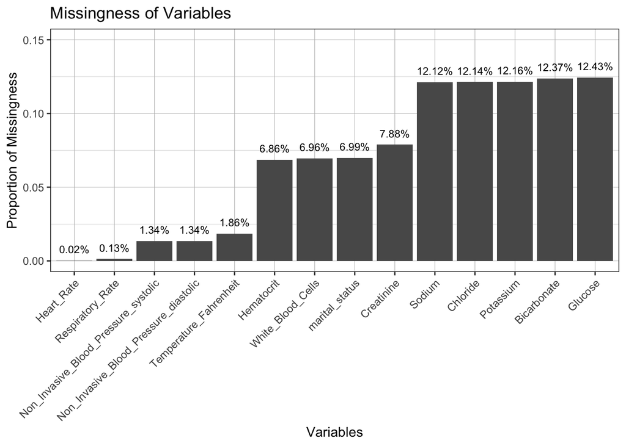

```r
# display the missing distribution of the variables and visualize it
mimic_icu_cohort |>
  map_df(~sum(is.na(.x))/nrow(mimic_icu_cohort)) |>
  gather(variable, missing) |>
  filter(missing > 0) |>
  arrange(desc(missing)) |>
  ggplot(aes(x = reorder(variable, missing), y = missing)) +
  geom_col() +
  labs(title = "Missingness of Variables",
       x = "Variables",
       y = "Proportion of Missingness") +
  # display the value of the bar and approximate to 0.01%
  geom_text(aes(label = scales::percent(missing, accuracy = 0.01)),
            vjust = -1, size = 3) +
  coord_cartesian(ylim = c(0, 0.15)) +
  theme(axis.text.x = element_text(angle = 45, hjust=1)) +
  theme(panel.background = element_rect(fill = "white"),
        panel.grid = element_line(color = "gray", linewidth = 0.2),
        panel.border = element_rect(fill = NA, linewidth = 0.5))
```

Before imputing the missing values, I convert the outliers of the continuous variables to the missing values.

```r
# write a function to convert the outliers to missing values
outlier_to_na <- function(x) {
  q1 <- quantile(x, 0.25, na.rm = TRUE)
  q3 <- quantile(x, 0.75, na.rm = TRUE)
  iqr <- q3 - q1
  x[x < (q1 - 1.5 * iqr) | x > (q3 + 1.5 * iqr)] <- NA
  x
}

# convert the outliers (IQR method) to missing values for lab and vital events
mimic_icu_replace <- mimic_icu_cohort |>
  mutate(across(c(lab_vars, vital_vars), outlier_to_na))
```

Here, I use miceRanger to impute the missing values. To save render time, I check if the imputed dataset is already saved. If not, I impute the missing values using miceRanger and save the imputed dataset as `mimic_icu_mice.rds`.

```r
if (file.exists("mimic_icu_mice.rds")) {
  mimic_icu_mice <- read_rds("mimic_icu_mice.rds")
} else {
  # impute the missing values usingmiceRanger
  seqTime <- system.time(
    mimic_icu_mice <- miceRanger(
      mimic_icu_replace,
      m=3,
      maxit=10,
      returnModels = FALSE,
      verbose=TRUE
    )
  )
  mimic_icu_mice |>
    write_rds("mimic_icu_mice.rds")
}
```

To check the imputed values, I plot the distributions of the imputed variables (black) and compare with the original ones (red). From the plot, we can see that the imputed values are similar to the original ones, which means the imputation is successful.

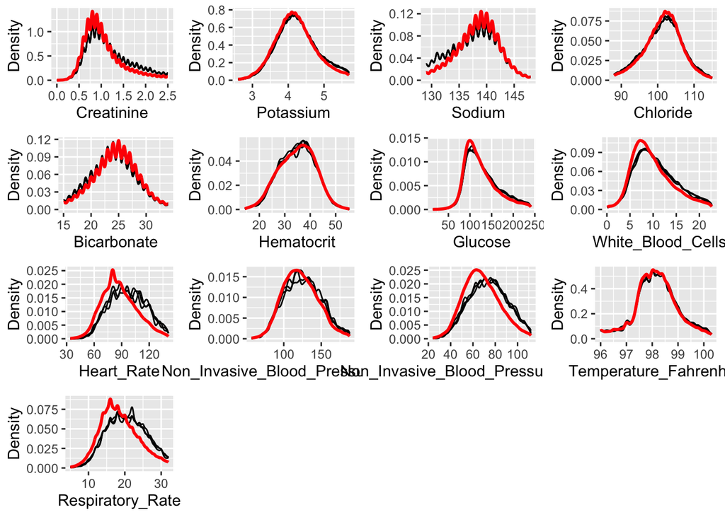

```r
# plot distributions of the imputed variables and compare with the original ones
plotDistributions(mimic_icu_mice, vars = 'allNumeric')
```

After imputing the missing values, I choose the first imputed dataset and convert non-numeric variables to factors and scale numeric variables.

```r
# choose the first imputed dataset
mimic_icu_imputed <- completeData(mimic_icu_mice)[[1]]

# convert non-numeric variables to factors and scale numeric variables
mimic_icu_final <- mimic_icu_imputed |>
  mutate_if(is.character, as.factor) |>
  mutate_if(is.numeric, scale) |>
  mutate_if(is.logical, as.factor)
```

## 2. Partition data into 50% training set and 50% test set

Stratify partitioning according to `los_long`. For grading purpose, sort the data by `subject_id`, `hadm_id`, and `stay_id` and use the seed `203` for the initial data split.

```r
library(rsample)
set.seed(203)

# sort
mimic_icu_final <- mimic_icu_final |>
  arrange(subject_id, hadm_id, stay_id)

data_split <- initial_split(
  mimic_icu_final,
  # stratify by los_long
  strata = "los_long",
  prop = 0.5
  )

data_split
```

```
<Training/Testing/Total>
<36590/36591/73181>
```

```r
# training set and test set
train_set <- training(data_split) |>
  select(-subject_id, -hadm_id, -stay_id)
dim(train_set)
```

```
[1] 36590    20
```

```r
test_set <- testing(data_split) |>
  select(-subject_id, -hadm_id, -stay_id)
dim(test_set)
```

```
[1] 36591    20
```

```r
# recipe
icu_recipe <- recipe(los_long ~ ., data = train_set) |>
  step_dummy(all_nominal_predictors()) |>
  step_zv(all_numeric_predictors()) |>
  print()
```

```
── Recipe ──────────────────────────────────────────────────────────────────────
```

```
── Inputs
```

```
Number of variables by role
```

```
outcome:    1
predictor: 19
```

```
── Operations
```

```
• Dummy variables from: all_nominal_predictors()
```

```
• Zero variance filter on: all_numeric_predictors()
```

## 3. Train and tune the models using the training set

Here I will use the logistic regression with enet regularization, random forest, boosting, and model stacking to predict whether a patient’s ICU stay will be longer than 2 days.

First I set up the cross-validation folds to be shared by all models.

```r
# set cross-validation partitions
set.seed(203)

folds <- vfold_cv(train_set, v = 5)
folds
```

```
#  5-fold cross-validation
# A tibble: 5 × 2
  splits               id
  <list>               <chr>
1 <split [29272/7318]> Fold1
2 <split [29272/7318]> Fold2
3 <split [29272/7318]> Fold3
4 <split [29272/7318]> Fold4
5 <split [29272/7318]> Fold5
```

### 3.1 Logistic regression with enet regularization

```r
logit_model <- logistic_reg(penalty = tune(), mixture = tune()) |>
  set_engine("glmnet", standardize = TRUE) |>
  print()
```

```
Logistic Regression Model Specification (classification)

Main Arguments:
  penalty = tune()
  mixture = tune()

Engine-Specific Arguments:
  standardize = TRUE

Computational engine: glmnet
```

```r
logit_wf <- workflow() |>
  add_recipe(icu_recipe) |>
  add_model(logit_model) |>
  print()
```

```
══ Workflow ════════════════════════════════════════════════════════════════════
Preprocessor: Recipe
Model: logistic_reg()

── Preprocessor ────────────────────────────────────────────────────────────────
2 Recipe Steps

• step_dummy()
• step_zv()

── Model ───────────────────────────────────────────────────────────────────────
Logistic Regression Model Specification (classification)

Main Arguments:
  penalty = tune()
  mixture = tune()

Engine-Specific Arguments:
  standardize = TRUE

Computational engine: glmnet
```

```r
# tuning grid
logit_grid <- grid_regular(
  penalty(range = c(-6, 3)),
  mixture(),
  levels = c(100, 5))

if (file.exists("logit_res.rds")) {
  logit_res <- read_rds("logit_res.rds")
} else {
  logit_res <-
    tune_grid(
      object = logit_wf,
      resamples = folds,
      grid = logit_grid,
      control = control_stack_grid()
    )
  write_rds(logit_res, "logit_res.rds")
}
```

```r
logit_res
```

```
# Tuning results
# 5-fold cross-validation
# A tibble: 5 × 5
  splits               id    .metrics             .notes           .predictions
  <list>               <chr> <list>               <list>           <list>
1 <split [29272/7318]> Fold1 <tibble [1,000 × 6]> <tibble [0 × 3]> <tibble>
2 <split [29272/7318]> Fold2 <tibble [1,000 × 6]> <tibble [0 × 3]> <tibble>
3 <split [29272/7318]> Fold3 <tibble [1,000 × 6]> <tibble [0 × 3]> <tibble>
4 <split [29272/7318]> Fold4 <tibble [1,000 × 6]> <tibble [0 × 3]> <tibble>
5 <split [29272/7318]> Fold5 <tibble [1,000 × 6]> <tibble [0 × 3]> <tibble>
```

```
# A tibble: 1,000 × 8
      penalty mixture .metric  .estimator  mean     n std_err
        <dbl>   <dbl> <chr>    <chr>      <dbl> <int>   <dbl>
 1 0.000001         0 accuracy binary     0.574     5 0.00211
 2 0.000001         0 roc_auc  binary     0.605     5 0.00224
 3 0.00000123       0 accuracy binary     0.574     5 0.00211
 4 0.00000123       0 roc_auc  binary     0.605     5 0.00224
 5 0.00000152       0 accuracy binary     0.574     5 0.00211
 6 0.00000152       0 roc_auc  binary     0.605     5 0.00224
 7 0.00000187       0 accuracy binary     0.574     5 0.00211
 8 0.00000187       0 roc_auc  binary     0.605     5 0.00224
 9 0.00000231       0 accuracy binary     0.574     5 0.00211
10 0.00000231       0 roc_auc  binary     0.605     5 0.00224
   .config
   <chr>
 1 Preprocessor1_Model001
 2 Preprocessor1_Model001
 3 Preprocessor1_Model002
 4 Preprocessor1_Model002
 5 Preprocessor1_Model003
 6 Preprocessor1_Model003
 7 Preprocessor1_Model004
 8 Preprocessor1_Model004
 9 Preprocessor1_Model005
10 Preprocessor1_Model005
# ℹ 990 more rows
```

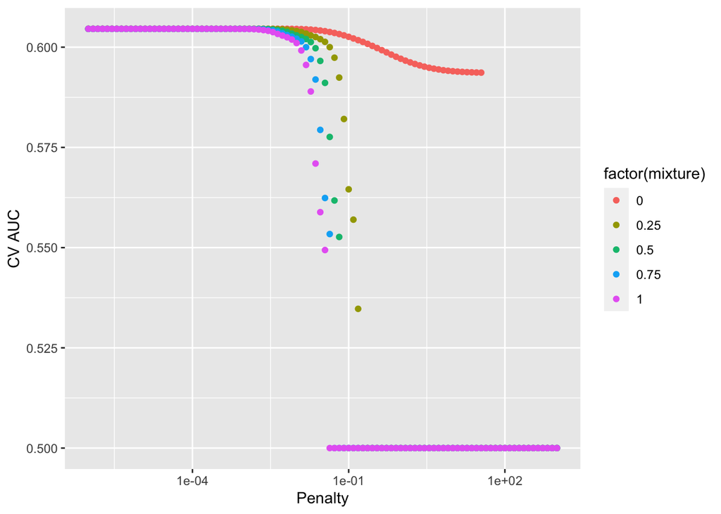

```r
logit_res |>
  # aggregate metrics from K folds
  collect_metrics() |>
  print(width = Inf) |>
  filter(.metric == "roc_auc") |>
  ggplot(mapping = aes(x = penalty, y = mean, color = factor(mixture))) +
  geom_point() +
  labs(x = "Penalty", y = "CV AUC") +
  scale_x_log10()
```

```r
# Show the top 5 models
logit_res |>
  show_best("roc_auc")
```

```
# A tibble: 5 × 8
     penalty mixture .metric .estimator  mean     n std_err .config
       <dbl>   <dbl> <chr>   <chr>      <dbl> <int>   <dbl> <chr>
1 0.000001         0 roc_auc binary     0.605     5 0.00224 Preprocessor1_Model…
2 0.00000123       0 roc_auc binary     0.605     5 0.00224 Preprocessor1_Model…
3 0.00000152       0 roc_auc binary     0.605     5 0.00224 Preprocessor1_Model…
4 0.00000187       0 roc_auc binary     0.605     5 0.00224 Preprocessor1_Model…
5 0.00000231       0 roc_auc binary     0.605     5 0.00224 Preprocessor1_Model…
```

```r
# select the best model
best_logit <- logit_res |>
  select_best("roc_auc")
best_logit
```

```
# A tibble: 1 × 3
   penalty mixture .config
     <dbl>   <dbl> <chr>
1 0.000001       0 Preprocessor1_Model001
```

```r
# Final workflow
final_logit <- logit_wf |>
  finalize_workflow(best_logit)
final_logit
```

```
══ Workflow ════════════════════════════════════════════════════════════════════
Preprocessor: Recipe
Model: logistic_reg()

── Preprocessor ────────────────────────────────────────────────────────────────
2 Recipe Steps

• step_dummy()
• step_zv()

── Model ───────────────────────────────────────────────────────────────────────
Logistic Regression Model Specification (classification)

Main Arguments:
  penalty = 1e-06
  mixture = 0

Engine-Specific Arguments:
  standardize = TRUE

Computational engine: glmnet
```

### 3.2 Random forest

```r
rf_mod <-
  rand_forest(
    mode = "classification",
    # Number of predictors randomly sampled in each split
    mtry = tune(),
    # Number of trees in ensemble
    trees = tune()
  ) |>
  set_engine("ranger", importance = "impurity")
rf_mod
```

```
Random Forest Model Specification (classification)

Main Arguments:
  mtry = tune()
  trees = tune()

Engine-Specific Arguments:
  importance = impurity

Computational engine: ranger
```

```r
rf_wf <- workflow() |>
  add_recipe(icu_recipe) |>
  add_model(rf_mod)
rf_wf
```

```
══ Workflow ════════════════════════════════════════════════════════════════════
Preprocessor: Recipe
Model: rand_forest()

── Preprocessor ────────────────────────────────────────────────────────────────
2 Recipe Steps

• step_dummy()
• step_zv()

── Model ───────────────────────────────────────────────────────────────────────
Random Forest Model Specification (classification)

Main Arguments:
  mtry = tune()
  trees = tune()

Engine-Specific Arguments:
  importance = impurity

Computational engine: ranger
```

```r
rf_grid <- grid_regular(
  trees(range = c(300L, 800L)),
  mtry(range = c(1L, 5L)),
  levels = c(10, 10)
  )

if (file.exists("rf_res.rds")) {
  rf_res <- read_rds("rf_res.rds")
} else {
  rf_res <-
  tune_grid(
    object = rf_wf,
    resamples = folds,
    grid = rf_grid,
    control = control_stack_grid()
  )
  write_rds(rf_res, "rf_res.rds")
}
rf_res
```

```
# Tuning results
# 5-fold cross-validation
# A tibble: 5 × 5
  splits               id    .metrics           .notes           .predictions
  <list>               <chr> <list>             <list>           <list>
1 <split [29272/7318]> Fold1 <tibble [100 × 6]> <tibble [0 × 3]> <tibble>
2 <split [29272/7318]> Fold2 <tibble [100 × 6]> <tibble [0 × 3]> <tibble>
3 <split [29272/7318]> Fold3 <tibble [100 × 6]> <tibble [0 × 3]> <tibble>
4 <split [29272/7318]> Fold4 <tibble [100 × 6]> <tibble [0 × 3]> <tibble>
5 <split [29272/7318]> Fold5 <tibble [100 × 6]> <tibble [0 × 3]> <tibble>
```

```
# A tibble: 100 × 8
    mtry trees .metric  .estimator  mean     n std_err .config
   <int> <int> <chr>    <chr>      <dbl> <int>   <dbl> <chr>
 1     1   300 accuracy binary     0.572     5 0.00274 Preprocessor1_Model01
 2     1   300 roc_auc  binary     0.611     5 0.00255 Preprocessor1_Model01
 3     1   355 accuracy binary     0.573     5 0.00408 Preprocessor1_Model02
 4     1   355 roc_auc  binary     0.613     5 0.00249 Preprocessor1_Model02
 5     1   411 accuracy binary     0.572     5 0.00375 Preprocessor1_Model03
 6     1   411 roc_auc  binary     0.613     5 0.00195 Preprocessor1_Model03
 7     1   466 accuracy binary     0.572     5 0.00479 Preprocessor1_Model04
 8     1   466 roc_auc  binary     0.614     5 0.00206 Preprocessor1_Model04
 9     1   522 accuracy binary     0.572     5 0.00382 Preprocessor1_Model05
10     1   522 roc_auc  binary     0.613     5 0.00260 Preprocessor1_Model05
# ℹ 90 more rows
```

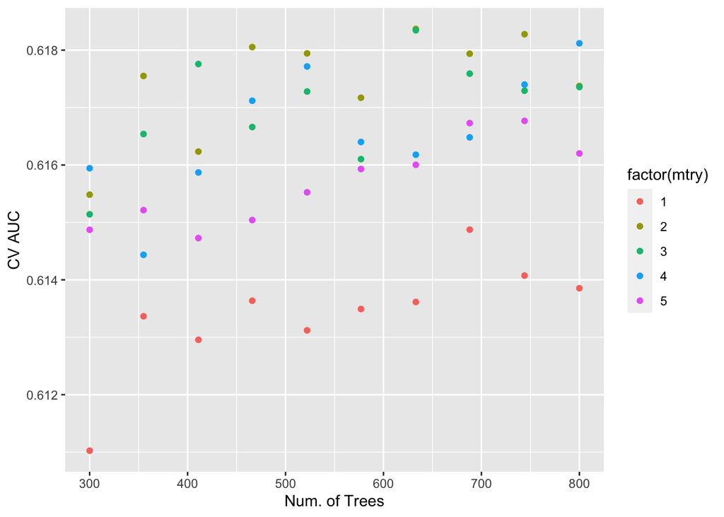

```r
# visualize CV results
rf_res |>
  collect_metrics() |>
  print(width = Inf) |>
  filter(.metric == "roc_auc") |>
  ggplot(mapping = aes(x = trees, y = mean, color = factor(mtry))) +
  geom_point() +
  # geom_line() +
  labs(x = "Num. of Trees", y = "CV AUC")
```

```r
# the top 5 models
rf_res |>
  show_best("roc_auc")
```

```
# A tibble: 5 × 8
   mtry trees .metric .estimator  mean     n std_err .config
  <int> <int> <chr>   <chr>      <dbl> <int>   <dbl> <chr>
1     2   633 roc_auc binary     0.618     5 0.00214 Preprocessor1_Model17
2     3   633 roc_auc binary     0.618     5 0.00221 Preprocessor1_Model27
3     2   744 roc_auc binary     0.618     5 0.00254 Preprocessor1_Model19
4     4   800 roc_auc binary     0.618     5 0.00213 Preprocessor1_Model40
5     2   466 roc_auc binary     0.618     5 0.00220 Preprocessor1_Model14
```

```r
best_rf <- rf_res |>
  select_best("roc_auc")
best_rf
```

```
# A tibble: 1 × 3
   mtry trees .config
  <int> <int> <chr>
1     2   633 Preprocessor1_Model17
```

```r
# Final workflow
final_rf <- rf_wf |>
  finalize_workflow(best_rf)
final_rf
```

```
══ Workflow ════════════════════════════════════════════════════════════════════
Preprocessor: Recipe
Model: rand_forest()

── Preprocessor ────────────────────────────────────────────────────────────────
2 Recipe Steps

• step_dummy()
• step_zv()

── Model ───────────────────────────────────────────────────────────────────────
Random Forest Model Specification (classification)

Main Arguments:
  mtry = 2
  trees = 633

Engine-Specific Arguments:
  importance = impurity

Computational engine: ranger
```

### 3.3 Boosting

```r
gb_mod <-
  boost_tree(
    mode = "classification",
    trees = 1000,
    tree_depth = tune(),
    learn_rate = tune()
  ) |>
  set_engine("xgboost")
gb_mod
```

```
Boosted Tree Model Specification (classification)

Main Arguments:
  trees = 1000
  tree_depth = tune()
  learn_rate = tune()

Computational engine: xgboost
```

```r
gb_wf <- workflow() |>
  add_recipe(icu_recipe) |>
  add_model(gb_mod)
gb_wf
```

```
══ Workflow ════════════════════════════════════════════════════════════════════
Preprocessor: Recipe
Model: boost_tree()

── Preprocessor ────────────────────────────────────────────────────────────────
2 Recipe Steps

• step_dummy()
• step_zv()

── Model ───────────────────────────────────────────────────────────────────────
Boosted Tree Model Specification (classification)

Main Arguments:
  trees = 1000
  tree_depth = tune()
  learn_rate = tune()

Computational engine: xgboost
```

```r
gb_grid <- grid_regular(
  tree_depth(range = c(1L, 5L)),
  learn_rate(range = c(-4, 1), trans = log10_trans()),
  levels = c(3, 10)
  )

if (file.exists("gb_res.rds")) {
  gb_res <- read_rds("gb_res.rds")
} else {
  gb_res <- tune_grid(
    object = gb_wf,
    resamples = folds,
    grid = gb_grid,
    control = control_stack_grid()
    )
  write_rds(gb_res, "gb_res.rds")
}
gb_res
```

```
# Tuning results
# 5-fold cross-validation
# A tibble: 5 × 5
  splits               id    .metrics          .notes           .predictions
  <list>               <chr> <list>            <list>           <list>
1 <split [29272/7318]> Fold1 <tibble [60 × 6]> <tibble [0 × 3]> <tibble>
2 <split [29272/7318]> Fold2 <tibble [60 × 6]> <tibble [0 × 3]> <tibble>
3 <split [29272/7318]> Fold3 <tibble [60 × 6]> <tibble [0 × 3]> <tibble>
4 <split [29272/7318]> Fold4 <tibble [60 × 6]> <tibble [0 × 3]> <tibble>
5 <split [29272/7318]> Fold5 <tibble [60 × 6]> <tibble [0 × 3]> <tibble>
```

```
# A tibble: 60 × 8
   tree_depth learn_rate .metric  .estimator  mean     n std_err
        <int>      <dbl> <chr>    <chr>      <dbl> <int>   <dbl>
 1          1   0.0001   accuracy binary     0.539     5 0.00381
 2          1   0.0001   roc_auc  binary     0.540     5 0.00566
 3          3   0.0001   accuracy binary     0.550     5 0.00465
 4          3   0.0001   roc_auc  binary     0.576     5 0.00425
 5          5   0.0001   accuracy binary     0.561     5 0.00515
 6          5   0.0001   roc_auc  binary     0.589     5 0.00356
 7          1   0.000359 accuracy binary     0.542     5 0.00458
 8          1   0.000359 roc_auc  binary     0.559     5 0.00426
 9          3   0.000359 accuracy binary     0.560     5 0.00479
10          3   0.000359 roc_auc  binary     0.587     5 0.00492
   .config
   <chr>
 1 Preprocessor1_Model01
 2 Preprocessor1_Model01
 3 Preprocessor1_Model02
 4 Preprocessor1_Model02
 5 Preprocessor1_Model03
 6 Preprocessor1_Model03
 7 Preprocessor1_Model04
 8 Preprocessor1_Model04
 9 Preprocessor1_Model05
10 Preprocessor1_Model05
# ℹ 50 more rows
```

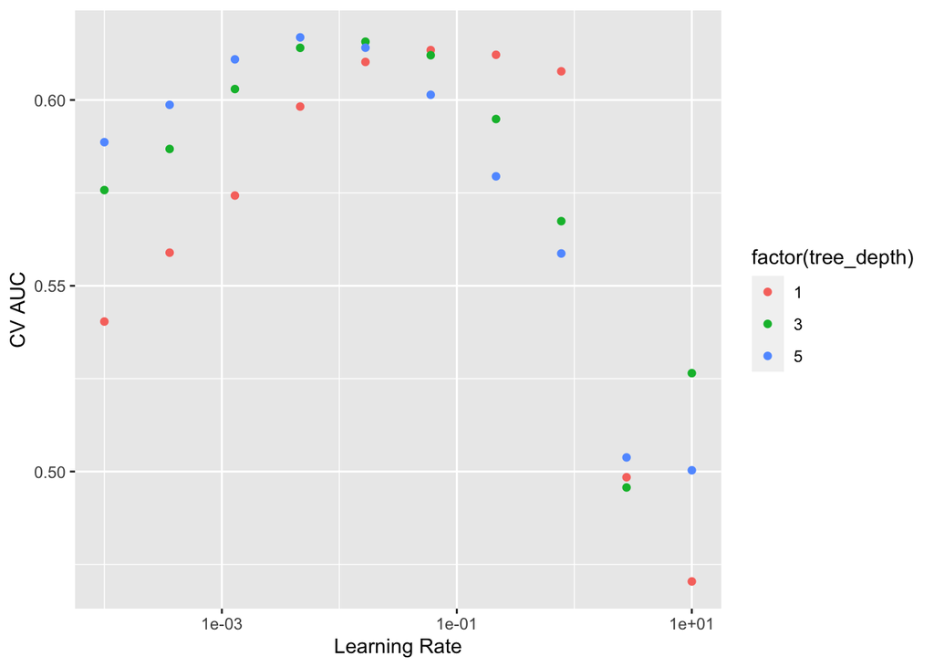

```r
gb_res |>
  collect_metrics() |>
  print(width = Inf) |>
  filter(.metric == "roc_auc") |>
  ggplot(mapping = aes(x = learn_rate, y = mean, color = factor(tree_depth))) +
  geom_point() +
  labs(x = "Learning Rate", y = "CV AUC") +
  scale_x_log10()
```

```r
# the top 5 models
gb_res |>
  show_best("roc_auc")
```

```
# A tibble: 5 × 8
  tree_depth learn_rate .metric .estimator  mean     n std_err .config
       <int>      <dbl> <chr>   <chr>      <dbl> <int>   <dbl> <chr>
1          5    0.00464 roc_auc binary     0.617     5 0.00193 Preprocessor1_Mo…
2          3    0.0167  roc_auc binary     0.616     5 0.00179 Preprocessor1_Mo…
3          5    0.0167  roc_auc binary     0.614     5 0.00153 Preprocessor1_Mo…
4          3    0.00464 roc_auc binary     0.614     5 0.00205 Preprocessor1_Mo…
5          1    0.0599  roc_auc binary     0.613     5 0.00188 Preprocessor1_Mo…
```

```r
# the best model
best_gb <- gb_res |>
  select_best("roc_auc")
best_gb
```

```
# A tibble: 1 × 3
  tree_depth learn_rate .config
       <int>      <dbl> <chr>
1          5    0.00464 Preprocessor1_Model12
```

```r
# Final workflow
final_gb <- gb_wf |>
  finalize_workflow(best_gb)
final_gb
```

```
══ Workflow ════════════════════════════════════════════════════════════════════
Preprocessor: Recipe
Model: boost_tree()

── Preprocessor ────────────────────────────────────────────────────────────────
2 Recipe Steps

• step_dummy()
• step_zv()

── Model ───────────────────────────────────────────────────────────────────────
Boosted Tree Model Specification (classification)

Main Arguments:
  trees = 1000
  tree_depth = 5
  learn_rate = 0.00464158883361278

Computational engine: xgboost
```

### 3.4 Model stacking

```r
if (file.exists("icu_model_st.rds")) {
  icu_model_st <- read_rds("icu_model_st.rds")
} else {
  icu_model_st <-
    stacks() |>
    add_candidates(logit_res) |>
    add_candidates(rf_res) |>
    add_candidates(gb_res) |>
    blend_predictions(
      penalty = 10^(-6:2),
      metrics = c("roc_auc")
      ) |>
    fit_members()
  write_rds(icu_model_st, "icu_model_st.rds")
}
```

```r
icu_model_st
```

```
── A stacked ensemble model ─────────────────────────────────────


Out of 216 possible candidate members, the ensemble retained 15.

Penalty: 0.01.

Mixture: 1.


The 10 highest weighted member classes are:
```

```
# A tibble: 10 × 3
   member                     type         weight
   <chr>                      <chr>         <dbl>
 1 .pred_TRUE_gb_res_1_12     boost_tree    0.719
 2 .pred_TRUE_rf_res_1_40     rand_forest   0.627
 3 .pred_TRUE_rf_res_1_27     rand_forest   0.606
 4 .pred_TRUE_logit_res_1_001 logistic_reg  0.574
 5 .pred_TRUE_rf_res_1_12     rand_forest   0.460
 6 .pred_TRUE_gb_res_1_17     boost_tree    0.361
 7 .pred_TRUE_rf_res_1_35     rand_forest   0.342
 8 .pred_TRUE_rf_res_1_14     rand_forest   0.333
 9 .pred_TRUE_rf_res_1_17     rand_forest   0.315
10 .pred_TRUE_rf_res_1_23     rand_forest   0.190
```

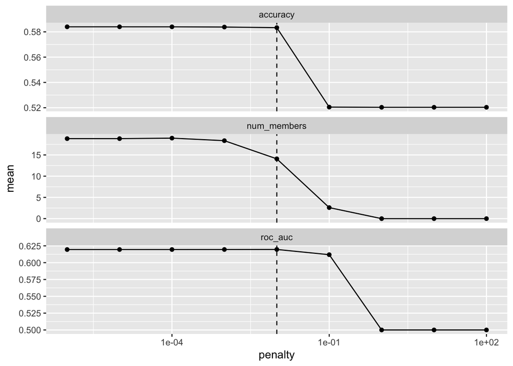

```r
# plot the results
autoplot(icu_model_st)
```

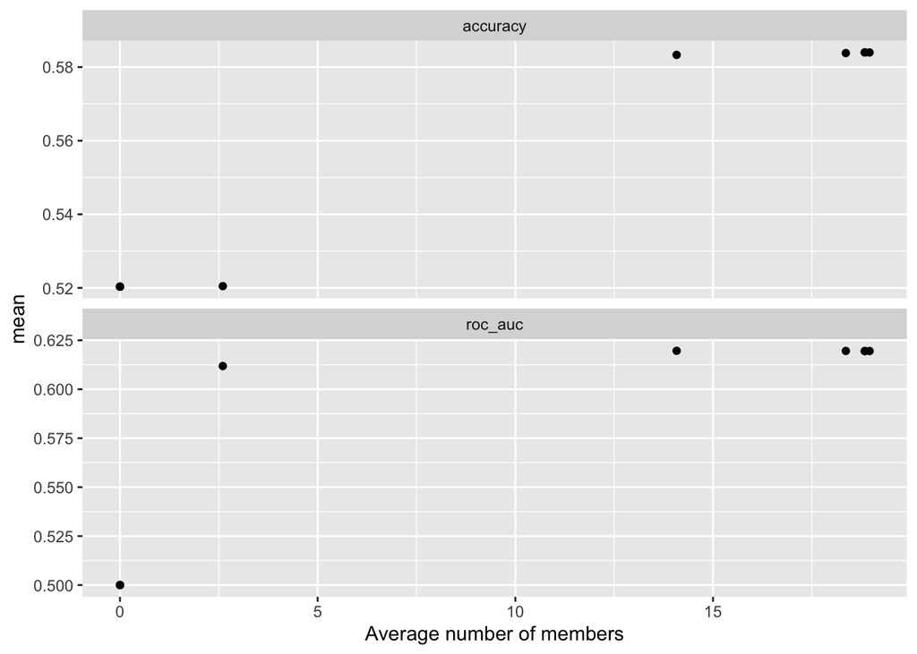

```r
autoplot(icu_model_st, type = "members")
```

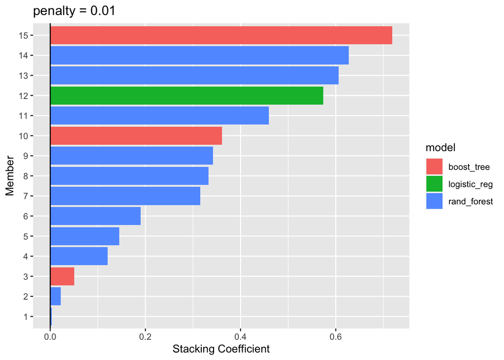

```r
autoplot(icu_model_st, type = "weights")
```

## 4. Compare model classification performance on the test set

Report both the area under ROC curve and accuracy for each machine learning algorithm and the model stacking. Interpret the results. What are the most important features in predicting long ICU stays? How do the models compare in terms of performance and interpretability?

### 4.1 AUC and accuracy of each model

#### 4.1.1 Logistic regression with enet regularization

```r
# Fit the whole training set, then predict the test cases based on logistic regression
logit_fit <-
  final_logit |>
  last_fit(data_split)

# Test metrics
logit_fit |>
  collect_metrics()
```

```
# A tibble: 2 × 4
  .metric  .estimator .estimate .config
  <chr>    <chr>          <dbl> <chr>
1 accuracy binary         0.574 Preprocessor1_Model1
2 roc_auc  binary         0.600 Preprocessor1_Model1
```

#### 4.1.2 Random forest

```r
# Fit the whole training set, then predict the test cases based on RF
rf_fit <-
  final_rf |>
  last_fit(data_split)

# Test metrics
rf_fit |>
  collect_metrics()
```

```
# A tibble: 2 × 4
  .metric  .estimator .estimate .config
  <chr>    <chr>          <dbl> <chr>
1 accuracy binary         0.586 Preprocessor1_Model1
2 roc_auc  binary         0.619 Preprocessor1_Model1
```

#### 4.1.3 Boosting

```r
# Fit the whole training set, then predict the test cases based on GB
gb_fit <-
  final_gb |>
  last_fit(data_split)

# Test metrics
gb_fit |>
  collect_metrics()
```

```
# A tibble: 2 × 4
  .metric  .estimator .estimate .config
  <chr>    <chr>          <dbl> <chr>
1 accuracy binary         0.582 Preprocessor1_Model1
2 roc_auc  binary         0.617 Preprocessor1_Model1
```

#### 4.1.4 Model stacking

```r
# predict the test set
icu_test_pred_st <-
  icu_model_st |>
  predict(test_set, type = "prob") |>
  bind_cols(test_set) |>
  print()
```

```
# A tibble: 36,591 × 22
   .pred_FALSE .pred_TRUE race  insurance marital_status gender first_careunit
         <dbl>      <dbl> <fct> <fct>     <fct>          <fct>  <fct>
 1       0.541      0.459 WHITE Medicaid  WIDOWED        F      Medical Intensi…
 2       0.527      0.473 WHITE Other     MARRIED        F      Surgical Intens…
 3       0.634      0.366 WHITE Other     MARRIED        F      Surgical Intens…
 4       0.546      0.454 WHITE Other     MARRIED        F      Medical/Surgica…
 5       0.613      0.387 Other Medicare  SINGLE         F      Cardiac Vascula…
 6       0.538      0.462 WHITE Other     MARRIED        F      Other
 7       0.364      0.636 WHITE Medicare  WIDOWED        F      Medical Intensi…
 8       0.431      0.569 WHITE Medicare  WIDOWED        F      Medical Intensi…
 9       0.522      0.478 WHITE Medicare  WIDOWED        M      Other
10       0.360      0.640 Other Medicare  MARRIED        M      Other
# ℹ 36,581 more rows
# ℹ 15 more variables: Creatinine <dbl[,1]>, Potassium <dbl[,1]>,
#   Sodium <dbl[,1]>, Chloride <dbl[,1]>, Bicarbonate <dbl[,1]>,
#   Hematocrit <dbl[,1]>, Glucose <dbl[,1]>, White_Blood_Cells <dbl[,1]>,
#   Heart_Rate <dbl[,1]>, Non_Invasive_Blood_Pressure_systolic <dbl[,1]>,
#   Non_Invasive_Blood_Pressure_diastolic <dbl[,1]>,
#   Temperature_Fahrenheit <dbl[,1]>, Respiratory_Rate <dbl[,1]>, …
```

```r
# compute the AUC
st_auc <- roc_auc(icu_test_pred_st, truth = los_long, .pred_FALSE)
st_auc
```

```
# A tibble: 1 × 3
  .metric .estimator .estimate
  <chr>   <chr>          <dbl>
1 roc_auc binary         0.622
```

```r
icu_pred_class <-
  test_set |>
  select(los_long) |>
  bind_cols(
    predict(
      icu_model_st,
      test_set,
      type = "class",
      members = TRUE
      )
    ) |>
  print()
```

```
       los_long .pred_class .pred_class_logit_res_1_001 .pred_class_rf_res_1_12
    1:    FALSE       FALSE                       FALSE                    TRUE
    2:    FALSE       FALSE                       FALSE                   FALSE
    3:    FALSE       FALSE                       FALSE                   FALSE
    4:    FALSE       FALSE                       FALSE                   FALSE
    5:    FALSE       FALSE                       FALSE                   FALSE
   ---
36587:    FALSE       FALSE                       FALSE                   FALSE
36588:    FALSE       FALSE                       FALSE                   FALSE
36589:    FALSE       FALSE                       FALSE                   FALSE
36590:     TRUE       FALSE                       FALSE                   FALSE
36591:     TRUE       FALSE                       FALSE                   FALSE
       .pred_class_rf_res_1_14 .pred_class_rf_res_1_17 .pred_class_rf_res_1_22
    1:                   FALSE                   FALSE                   FALSE
    2:                   FALSE                   FALSE                    TRUE
```

[output cut: 57 more lines]

```r
accuracy <- map(
  colnames(icu_pred_class),
  ~mean(icu_pred_class$los_long == pull(icu_pred_class, .x))
  ) |>
  set_names(colnames(icu_pred_class)) |>
  as_tibble() |>
  pivot_longer(c(everything(), -los_long), names_to = "model", values_to = "accuracy") |>
  # sort the accuracy
  arrange(desc(accuracy)) |>
  print()
```

```
# A tibble: 16 × 3
   los_long model                       accuracy
      <dbl> <chr>                          <dbl>
 1        1 .pred_class                    0.587
 2        1 .pred_class_rf_res_1_34        0.586
 3        1 .pred_class_rf_res_1_17        0.586
 4        1 .pred_class_rf_res_1_12        0.585
 5        1 .pred_class_rf_res_1_40        0.584
 6        1 .pred_class_rf_res_1_23        0.584
 7        1 .pred_class_rf_res_1_27        0.584
 8        1 .pred_class_rf_res_1_14        0.584
 9        1 .pred_class_rf_res_1_41        0.584
10        1 .pred_class_rf_res_1_31        0.584
11        1 .pred_class_gb_res_1_17        0.583
12        1 .pred_class_rf_res_1_35        0.583
13        1 .pred_class_gb_res_1_12        0.582
14        1 .pred_class_rf_res_1_22        0.581
15        1 .pred_class_gb_res_1_19        0.581
16        1 .pred_class_logit_res_1_001    0.574
```

```r
# save the accuracy of stacking model
st_accuracy <- accuracy$accuracy[1]
st_accu <- data.frame(
  .metric = "accuracy",
  .estimator = "binary",
  .estimate = st_accuracy
)
```

### 4.2 Feature importance

Here I plot the feature importance of the random forest and boosting models as follows. From the 2 plots, we can see that the most important features in predicting long ICU stays are `age_intime`, `Heart_Rate`, `Non_Invasive_Blood_Pressure_systolic`, `White_Blood_Cells`, `Glucose`, and `Hematocrit`. Among these features, `age_intime` is the patient’s age at ICU intime, `Heart_Rate` and `Non_Invasive_Blood_Pressure_systolic` are the first vital measurements during ICU stay, and `White_Blood_Cells`, `Glucose` and `Hematocrit` are the last lab measurements before the ICU stay.

```r
# feature importance of RF
fitted_wf <- rf_fit$.workflow[[1]]
fitted_model <- extract_fit_engine(fitted_wf)
importance <- fitted_model$variable.importance
importance_rf <- data.frame(
  Feature = names(importance),
  Importance = importance,
  stringsAsFactors = FALSE
)
importance_rf <- importance_rf[order(importance_rf$Importance, decreasing = TRUE), ]

# plot the feature importance
p <- ggplot(importance_rf, aes(x = reorder(Feature, Importance), y = Importance)) +
  geom_col() +
  coord_flip() +
  geom_text(aes(label = round(Importance, 2)), hjust = -0.1) +
  labs(x = "Features", y = "Importance",
       title = "Feature Importance in Random Forest Model") +
  theme(panel.background = element_rect(fill = "white"),
        panel.grid = element_line(color = "gray", linewidth = 0.2),
        panel.border = element_rect(fill = NA, linewidth = 0.5))

ggsave("feature_importance_rf.png", p, width = 18, height = 8)
```

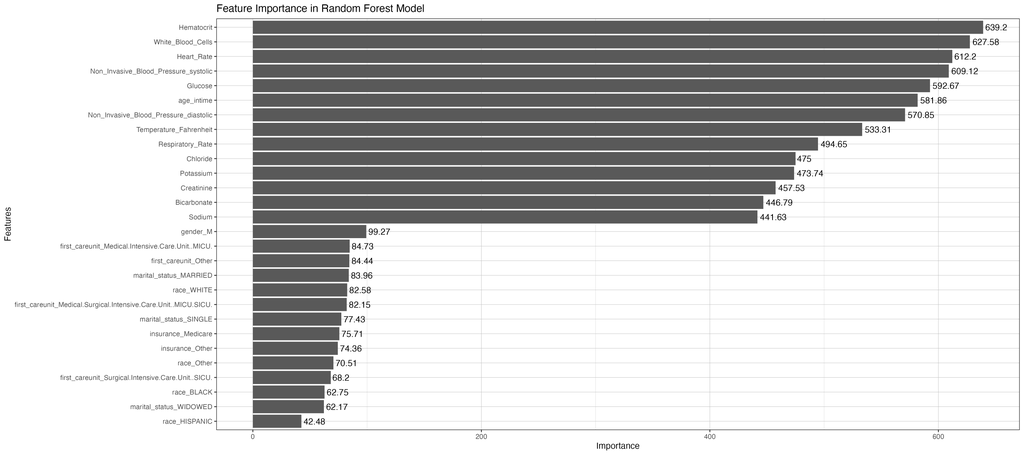

Feature Importance of RF

```r
# feature importance of GB
fitted_gbwf <- gb_fit$.workflow[[1]]
fitted_gbmodel <- extract_fit_engine(fitted_gbwf)
importance_gb <- xgb.importance(model = fitted_gbmodel)

p <- ggplot(importance_gb, aes(x = reorder(Feature, Gain), y = Gain)) +
  geom_col() +
  coord_flip() +
  geom_text(aes(label = round(Gain, 2)), hjust = -0.1) +
  labs(x = "Features", y = "Gain",
       title = "Feature Importance in Gradient Boosting Model") +
  theme(panel.background = element_rect(fill = "white"),
        panel.grid = element_line(color = "gray", linewidth = 0.2),
        panel.border = element_rect(fill = NA, linewidth = 0.5))

ggsave("feature_importance_gb.png", p, width = 18, height = 8)
```

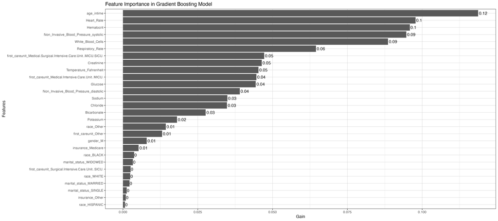

Feature Importance of XGB

### 4.3 Model comparison in terms of performance and interpretability

#### 4.3.1 Performance (stacking > RF > XGB > logit)

From the performance table and ROC curves below, we can see that

- Model Stacking shows the best performance in terms of both accuracy and ROC AUC, slightly outperforming the other models. This indicates that combining the predictions of multiple models can lead to a slight improvement in predictive performance.
- Random Forest and Boosting models perform similarly and better than logistic regression, suggesting that tree-based methods may capture complex patterns in the data more effectively.
- Logistic Regression shows the lowest performance among the models in both metrics, which might be due to its linear nature being less capable of handling complex relationships in the data.

```r
# compare the models in terms of performance
library(broom)
metrics_list <- list(
  logit = logit_fit %>% collect_metrics(),
  rf = rf_fit %>% collect_metrics(),
  boosting = gb_fit %>% collect_metrics(),
  stacking = st_accu,
  stacking = st_auc
)

bind_rows(metrics_list, .id = "model") |>
  filter(.metric == "accuracy" | .metric == "roc_auc") |>
  select(-.estimator, -.config) |>
  pivot_wider(names_from = .metric, values_from = .estimate) |>
  print()
```

```
# A tibble: 4 × 3
  model    accuracy roc_auc
  <chr>       <dbl>   <dbl>
1 logit       0.574   0.600
2 rf          0.586   0.619
3 boosting    0.582   0.617
4 stacking    0.587   0.622
```

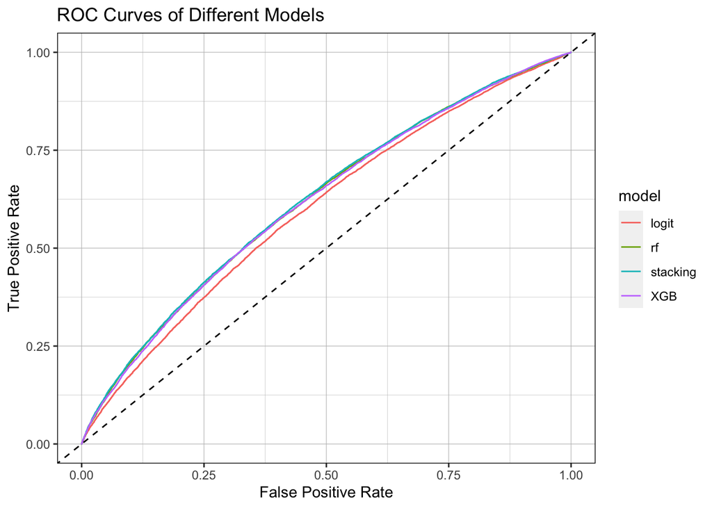

```r
# plot the ROC curves
library(yardstick)
logit_preds <- logit_fit |> collect_predictions()
rf_preds <- rf_fit |> collect_predictions()
gb_preds <- gb_fit |> collect_predictions()
logic_roc <- logit_preds |> roc_curve(los_long, .pred_FALSE)
rf_roc <- rf_preds |> roc_curve(los_long, .pred_FALSE)
gb_roc <- gb_preds |> roc_curve(los_long, .pred_FALSE)
st_roc <- icu_test_pred_st |> roc_curve(los_long, .pred_FALSE)
roc_curve <- bind_rows(
  logic_roc %>% mutate(model = "logit"),
  rf_roc %>% mutate(model = "rf"),
  gb_roc %>% mutate(model = "XGB"),
  st_roc %>% mutate(model = "stacking"))
roc_curve |> ggplot(aes(x = 1 - specificity, y = sensitivity, color = model)) +
  geom_line() +
  geom_abline(slope = 1, intercept = 0, linetype = "dashed") +
  labs(title = "ROC Curves of Different Models",
       x = "False Positive Rate",
       y = "True Positive Rate") +
  theme(panel.background = element_rect(fill = "white"),
        panel.grid = element_line(color = "gray", linewidth = 0.2),
        panel.border = element_rect(fill = NA, linewidth = 0.5))
```

#### 4.3.2 Interpretability (logit > rf > XGB > stacking)

- Logistic Regression with ENet Regularization: High. Logistic regression models provide coefficients for each feature, making it straightforward to understand the impact of each feature on the prediction. Elastic Net regularization, which combines L1 and L2 penalties, can further enhance interpretability by promoting sparsity and reducing the influence of less important features.
- Random Forest: Moderate. While random forests offer insights into feature importance, indicating which features are most influential in making predictions, the ensemble nature of the model (comprising many decision trees) makes it harder to trace the exact decision path for specific predictions.
- Boosting Models: Moderate to Low. Similar to random forests, boosting models can provide measures of feature importance. However, the sequential correction of errors in boosting adds complexity, making the exact reasoning behind predictions less transparent than simpler models.
- Model Stacking: Low. Stacking involves combining the predictions from multiple models, which inherently reduces interpretability. Understanding how individual predictions contribute to the final decision can be challenging, as it depends on the interplay between different base models and possibly a meta-model.

#### 4.3.3 Conclusion on model comparison

In summary, the choice of model should consider the trade-off between performance and interpretability. Logistic regression offers high interpretability but lower performance, while random forests and boosting models provide a good balance between the two. Model stacking, while showing a slight performance advantage, sacrifices interpretability due to its complex nature. Therefore, the choice of model should be based on the specific needs of the application, considering the importance of interpretability, the complexity of the data, and the desired level of predictive performance.

## 5. Conclusions

In this homework, I developed machine learning approaches to predict whether a patient’s ICU stay will be longer than 2 days using the MIMIC-IV ICU cohort. I preprocessed the data, partitioned it into training and test sets, and trained and tuned logistic regression with enet regularization, random forest, boosting, and model stacking models. I compared the classification performance of the models on the test set, identified the most important features in predicting long ICU stays, and evaluated the models in terms of performance and interpretability. The results showed that model stacking slightly outperformed the other models in terms of accuracy and ROC AUC, while logistic regression provided the highest interpretability.